# Genetic Components of PCA

ASintsova

4/20/2017

## Goals

1. Re-normalize ‘normalized’ data and re-do the PCA to see if there are any drastic changes
2. Using PCA from re-normalized data determine PC2 (phylogroup) component loadings for combined data, urine alone, uti alone
3. Run phylogenetic tests on genes identified to see if they show ‘phylogenetic signal’
4. Come up with further plan of action

## 1. Re-normalize ‘normalized’ data and re-do the PCA to see if there are any drastic changes

- From Steve:

```r
invnorm = function(x) { qnorm((rank(x,na.last="keep",ties.method="random")-0.5)/sum(!is.na(x))); }
```

- From the internet

```r
my.invnorm = function(x)
{
 res = rank(x)
 res = qnorm(res/(length(res)+0.5))
 return(res)
}
```

- Import normalized counts & expreiment_info: count distribution is very far from normal

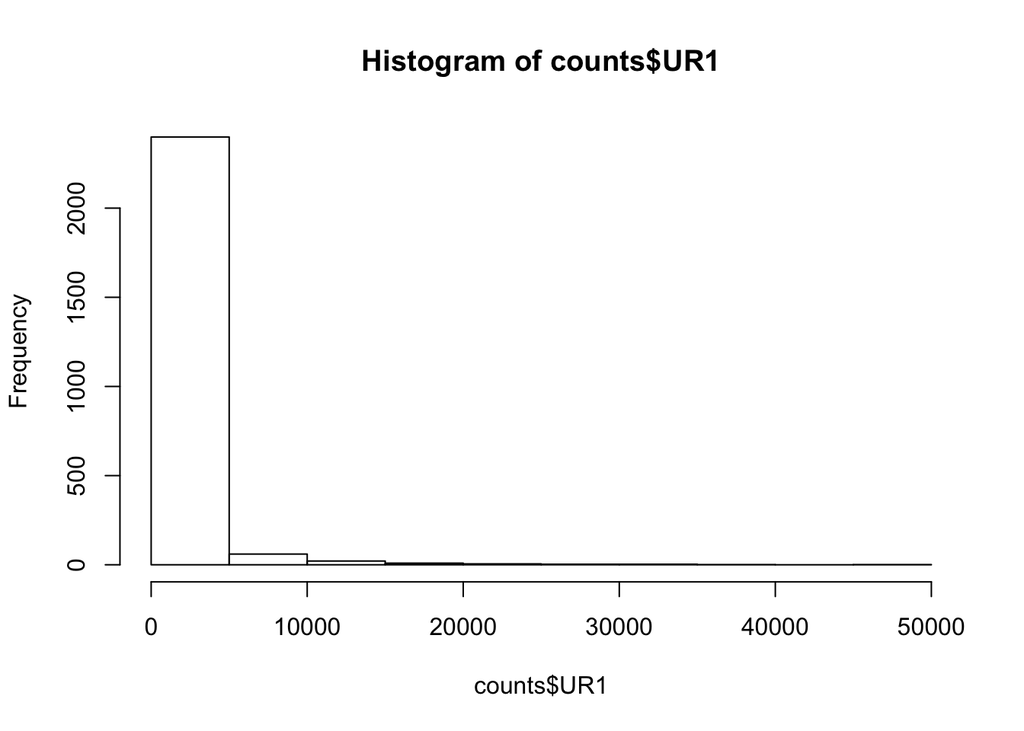

- If we do log2 transform, looks much better

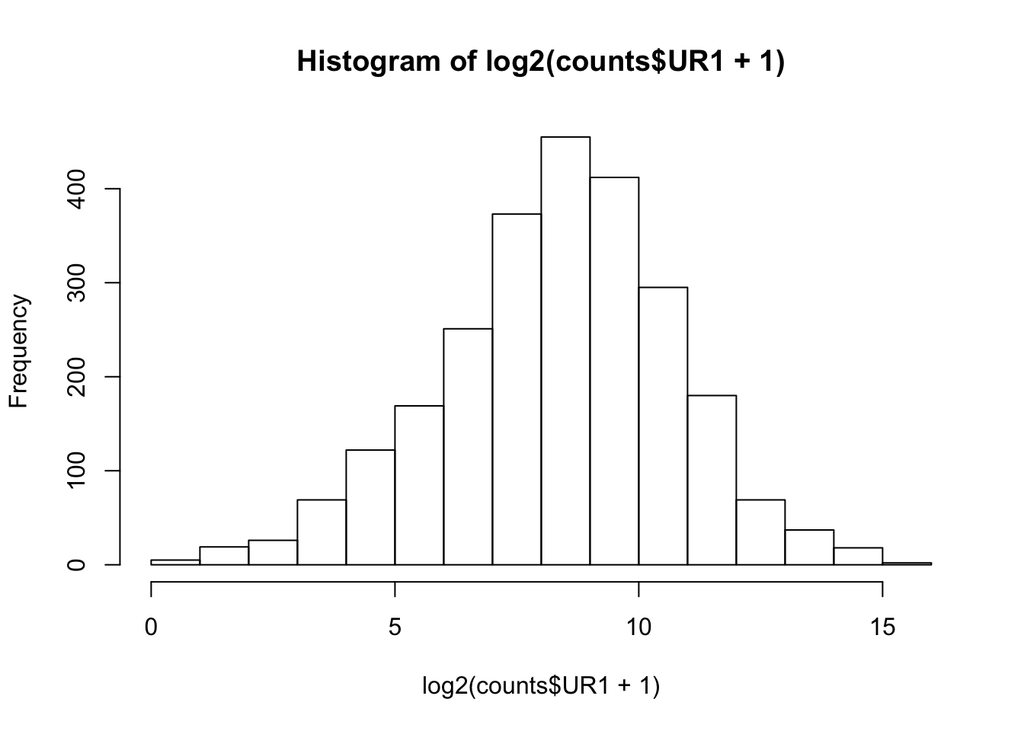

- Steve’s inverse normalization

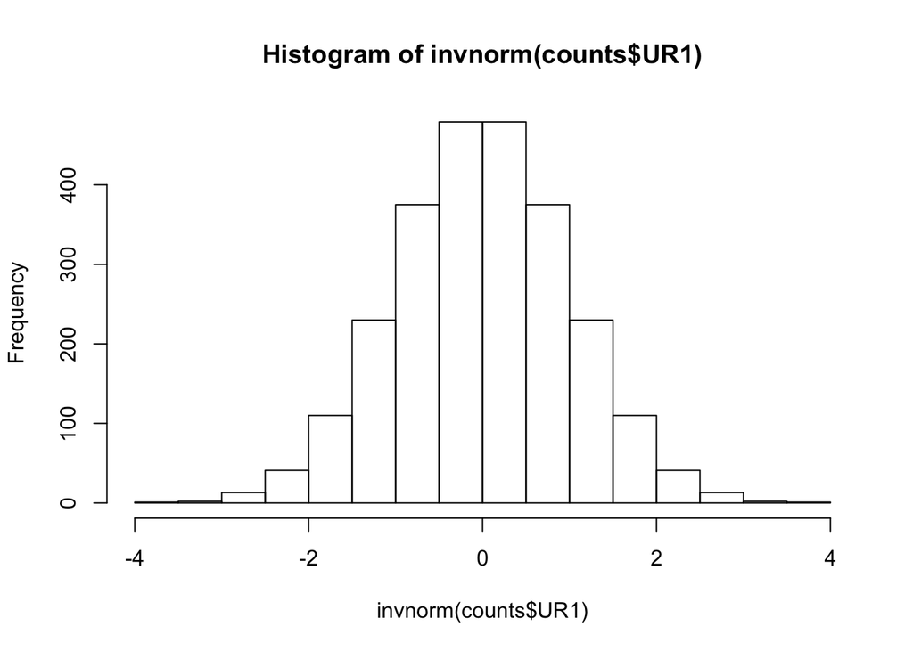

```r
 hist(invnorm(counts$UR1))
```

- And using the other formula:

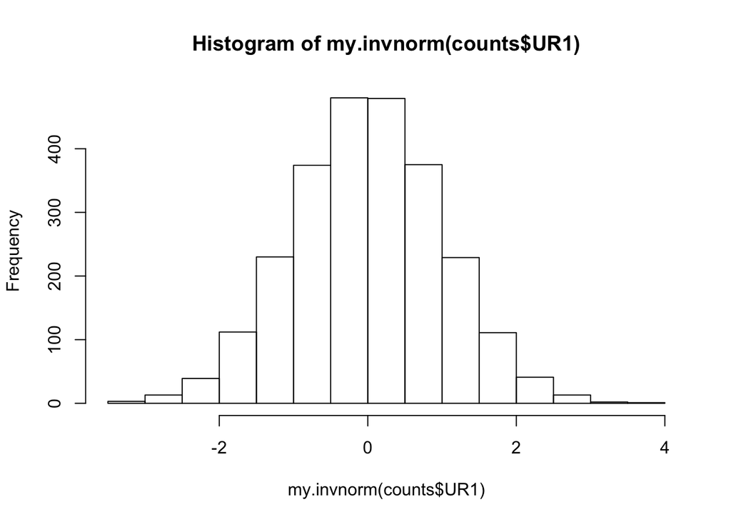

```r
 hist(my.invnorm(counts$UR1))
```

- Inverse normalizing all the data

```
##                                   UR1       UTI1       UR3      UTI3
## 14805_sufB_1                0.5852891 -0.3257622 -1.914506 -1.807121
## 14806_iscA_1               -0.2227360 -1.0309635 -2.604805 -2.382699
## 14807_hypothetical_protein  0.4756938  0.5616705 -2.669611 -2.349771
## 14808_ydiI_1               -0.2640173 -0.3576256 -3.239108 -3.090470
## 14813_hypothetical_protein -1.8174732 -1.6471833 -3.540295 -2.848218
## 14816_ydiB_1               -1.0481612 -1.2673338 -2.706749 -2.418433
##                                    UR6       UTI6        UR7       UTI7
## 14805_sufB_1                0.57107966  0.9523347  1.1469582  1.3649709
## 14806_iscA_1                0.04158875  0.1513543  0.4824358  0.5383612
## 14807_hypothetical_protein  0.22787399  0.2910891  0.3985188  0.4246893
## 14808_ydiI_1               -0.30995560 -0.1950884 -0.7453913 -0.8063103
## 14813_hypothetical_protein -1.86665029 -1.6832529 -1.5337144 -1.7350395
## 14816_ydiB_1               -0.50165919 -1.1606031 -0.4959863 -2.1599650
##                                   UR14       UTI14       UR17      UTI17
## 14805_sufB_1                1.19467450 -0.08777444  1.0656746 -0.2733654
## 14806_iscA_1                0.53720344 -0.79251997  0.5039329 -0.6310962
## 14807_hypothetical_protein  0.07169363 -0.33210741  0.3801461 -0.3640411
## 14808_ydiI_1               -0.46450473 -0.53142558 -0.2001965 -0.5176303
## 14813_hypothetical_protein -1.49279213 -2.07518250 -1.1744675 -2.6358256
## 14816_ydiB_1               -0.34377542 -0.74803930 -0.4290790 -1.9467997
##                                   UR43      UTI43        UR54       UTI54
## 14805_sufB_1                0.34058866  1.4427861  1.53371444  0.71401189
## 14806_iscA_1               -0.26090643  0.8836254  0.78977998 -0.07370263
## 14807_hypothetical_protein  0.26090643  0.3469657  0.15439517 -0.19610960
## 14808_ydiI_1               -0.05262139 -0.3036548  0.02354565 -0.35122486
## 14813_hypothetical_protein -1.69577733 -2.0259902 -1.30162221 -1.73054374
## 14816_ydiB_1               -0.66071833 -0.8357823 -0.33104895 -0.92894485
##                                   UR56        UTI56       UR57       UTI57
## 14805_sufB_1                1.16060307  0.141227973  1.2153815 -0.01853528
## 14806_iscA_1                0.63231930 -0.316268707  0.7586841 -0.56519308
## 14807_hypothetical_protein  0.41921371  0.009517717  0.6152808 -0.27544598
## 14808_ydiI_1                0.18998544 -0.265054827 -0.1058927 -1.11095730
## 14813_hypothetical_protein -1.48671414 -2.382698770 -1.4958519 -0.89403539
## 14816_ydiB_1               -0.05362466 -0.811869518 -0.4700919 -1.20703656
##                                  UR66       UTI66       UR68         UTI68
## 14805_sufB_1                1.0943968  0.40721114  0.2619431  0.5164851793
## 14806_iscA_1                0.4768159  0.04158875 -0.3747670  0.0005009249
## 14807_hypothetical_protein  0.5628439 -0.78841220  0.8616341  0.1513542929
## 14808_ydiI_1                0.2931801 -0.36832636  0.1503410 -0.4622739305
## 14813_hypothetical_protein -0.9876148 -1.42320665 -1.3624321 -1.5435316328
## 14816_ydiB_1               -0.5256654 -2.91148756 -0.2443569 -0.7140118950
##                                   UR86       UTI86
## 14805_sufB_1                1.29928854  0.74274861
## 14806_iscA_1                0.52336622  0.03056118
## 14807_hypothetical_protein  0.58291275  0.16454191
## 14808_ydiI_1                0.02354565 -0.26401730
## 14813_hypothetical_protein -1.60946827 -2.98912660
## 14816_ydiB_1               -0.29422611 -0.79939613
```

- Performing PCA analysis on these inverse normalized counts. Plotting all samples, label by media

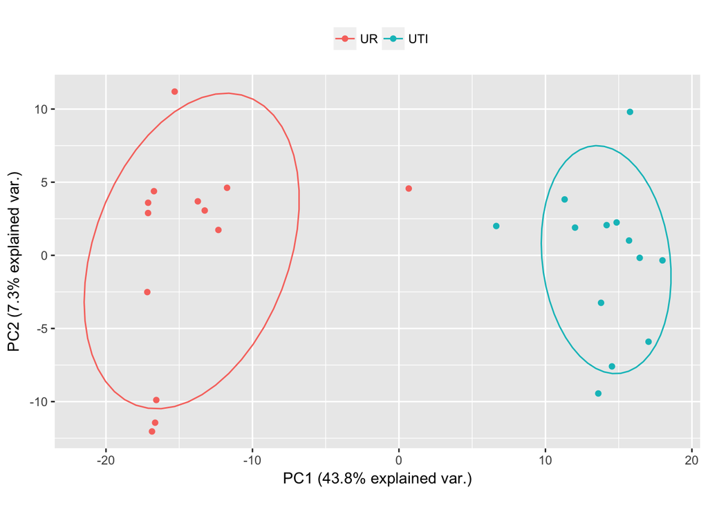

- Plotting all samples by phylogroup

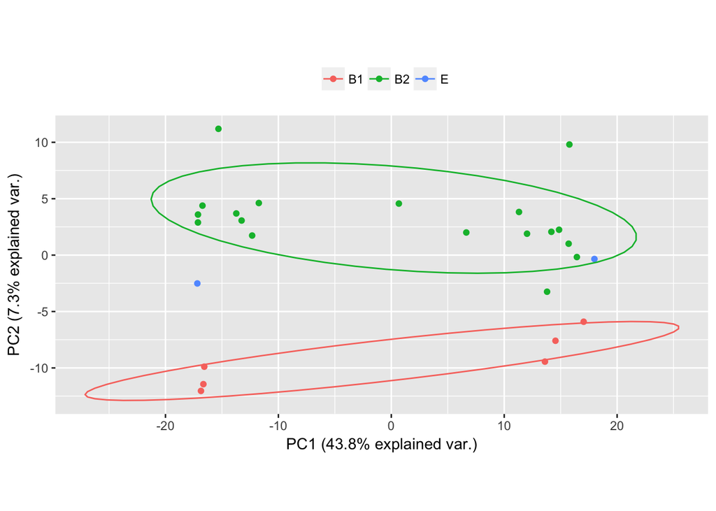

```r
g <- ggbiplot(all.pca, obs.scale = 1, var.scale = 1,
              groups = psg, ellipse = TRUE, circle = FALSE,
                var.axes = FALSE)
g <- g + scale_color_discrete(name = '')
g <- g + theme(legend.direction = 'horizontal',
                legend.position = 'top')
g
```

- Urine samples alone

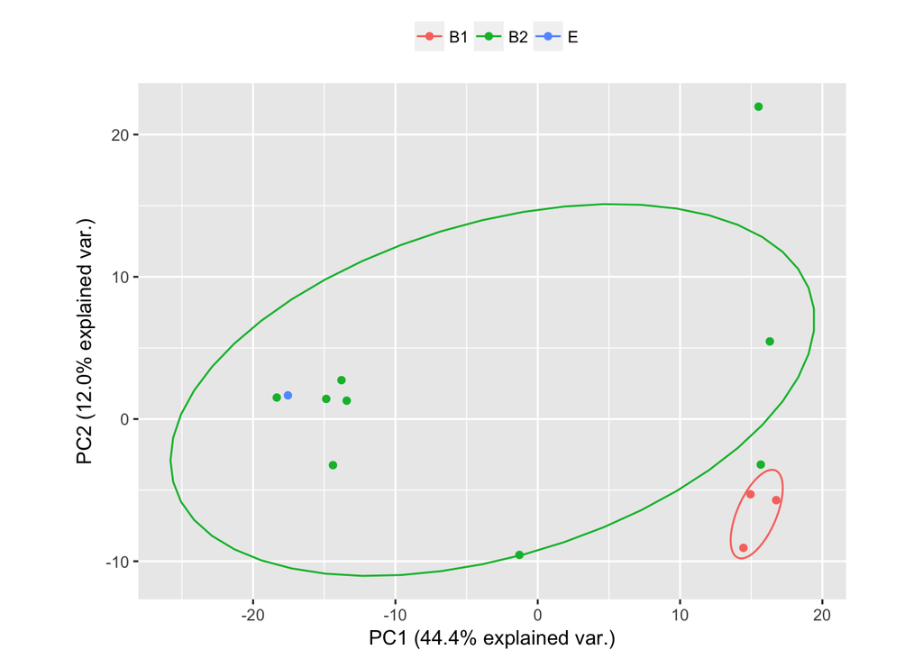

- Just for to see what would a random clustering look, plot by ‘history’

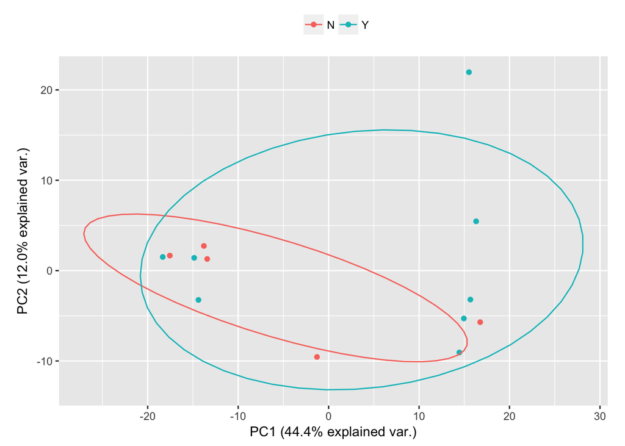

- UTI samples, by phylogroup

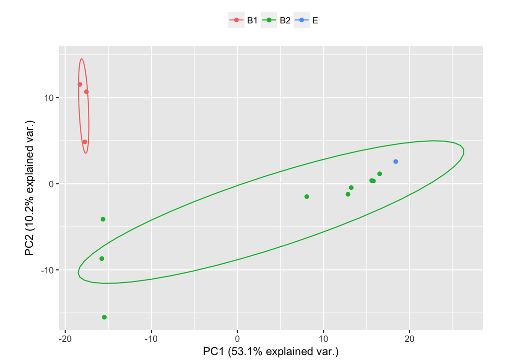

- UTI samples by history

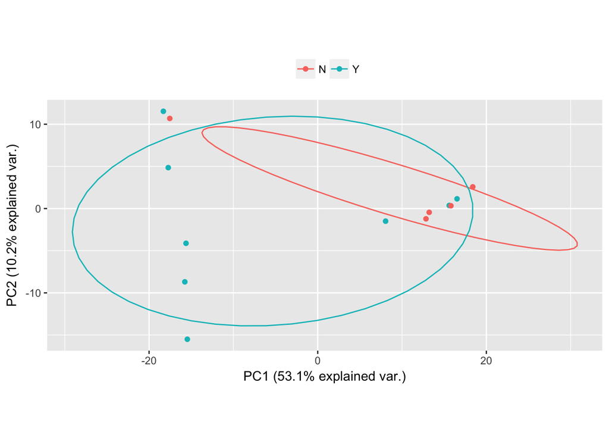

```r
g <- ggbiplot(uti.pca, obs.scale = 1, var.scale = 1,
              groups = uti.his, ellipse = TRUE, circle = FALSE,
                var.axes = FALSE)
g <- g + scale_color_discrete(name = '')
g <- g + theme(legend.direction = 'horizontal',
                legend.position = 'top')

g
```

## 2. Using PCA from re-normalized data determine PC2 (phylogroup) component loadings for combined data, urine alone, uti alone

- Determine PC2 loadings (a.k.a. rotation)

```r
annot = info[, c("MEDIA", "PRED_PHYLO")]
pca.data <- prcomp(t(inv.norm.c))
pc2.loadings <- pca.data$rotation[,2][order(pca.data$rotation[,2], decreasing = TRUE)][1:10]#PC2
names <- names(pc2.loadings)
load.genes <- inv.norm.c[names,]
head(names, 10)
```

```
##  [1] "15176_wzc"                  "15177_wzb"
##  [3] "17141_hypothetical_protein" "15747_trmD"
##  [5] "15010_argS"                 "15749_rpsP"
##  [7] "15748_rimM"                 "17023_sodA"
##  [9] "15750_ffh"                  "16160_parC"
```

- Visualize these

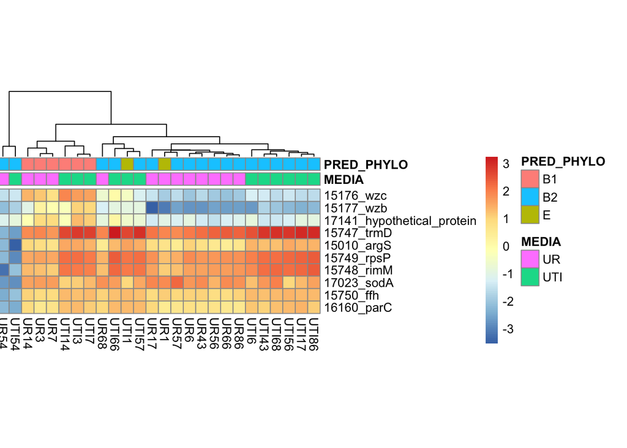

- Also look at PC1 loadings

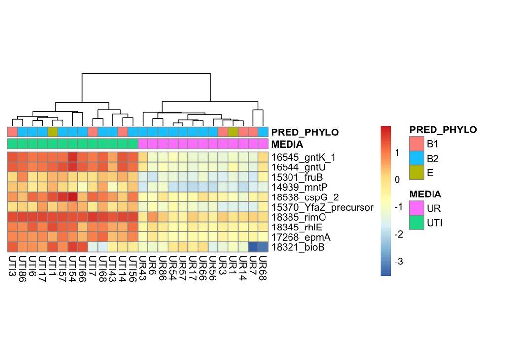

- Look at the location of these genes on B vs B1 genome, use HM14 and HM56

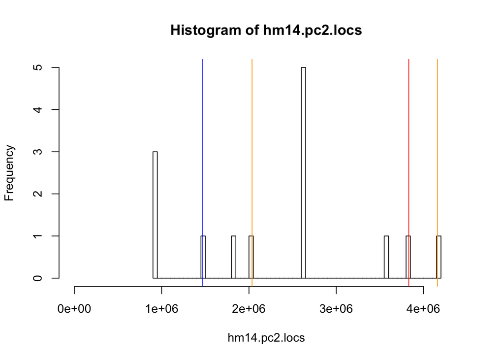

```r
hm14.pc2.locs <- c(3831641, 1816299, 933957, 2035632, 936157, 2615289, 2615678, 2616476, 2617043, 2617428,3570210, 937776, 4160540, 1465521 )
names(hm14.pc2.locs) <- c("ori","argS","wzc1", "wzc2", "wzb", "rplS", "trmD", "rimM", "rpsP", "ffh", "bcsB", "hypo1", "hypo2", "termi")
hist(hm14.pc2.locs, 100, xlim = c(0, 4400000))
abline(v = 1465521, col = 'blue')
abline(v = 3831641, col = 'red')
abline(v = 2035632, col = "orange")
abline(v = 4160540, col = "orange" )
```

- HM56

```r
all.locs <- read.table(paste0(data, "pc2_ed.gff"), sep = "\t")
get_id <- function(x){
  gi <- unlist(strsplit(unlist(strsplit(x, c(";")))[1], "="))[2]
  return (gi)
}

g.ids<- sapply(as.character(all.locs[,3]), get_id)
all.locs[,3]<- g.ids
colnames(all.locs)<- c("genome", "location", "gene")


hm56.pc2 <- all.locs[all.locs$genome == "HM56_1",]
hm56.pc2.locs <- hm56.pc2$location
names(hm56.pc2.locs)<- hm56.pc2$gene

hm56.pc2.locs
```

```
##                 15010_argS                  15176_wzc
##                    2862631                    2612355
##                  15177_wzb                 15746_rplS
##                    2611909                    1998859
##                 15747_trmD                 15748_rimM
##                    1998050                    1997471
##                 15749_rpsP                  15750_ffh
##                    1997204                    1995706
##                 16642_bcsB 17141_hypothetical_protein
##                     994726                     409847
```

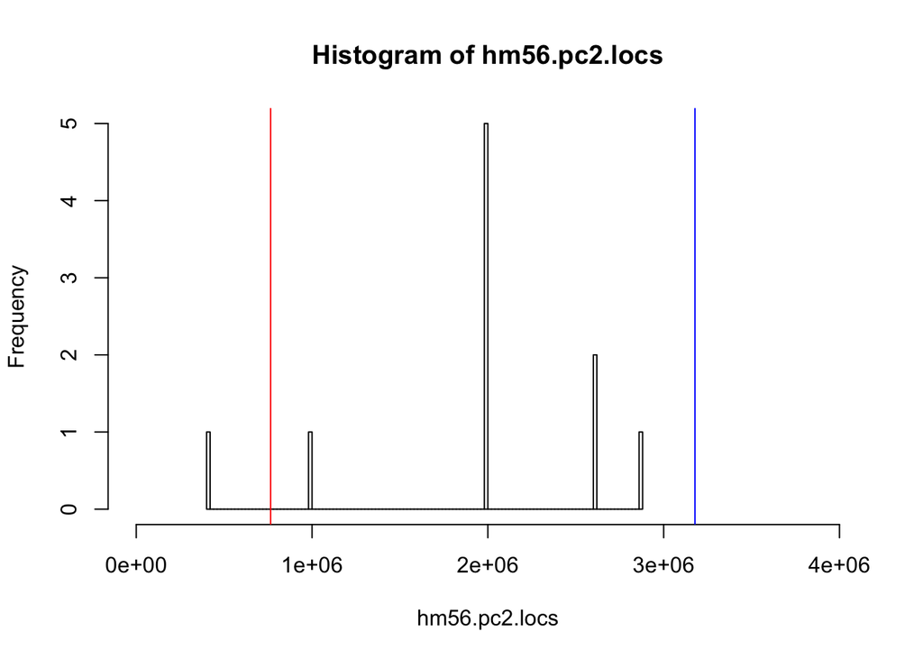

```r
hist(hm56.pc2.locs, 100, xlim = c(0, 4000000))
abline(v = 3177816, col = 'blue')
abline(v = 764444, col = 'red')
```

- Now do the same thing only using urine data and visualize

```r
annot = info[, c("MEDIA", "PRED_PHYLO")]
pca.data.urine <- prcomp(t.urine[,1:2502])
pc2.loadings.urine <- pca.data.urine$rotation[,2][order(pca.data.urine$rotation[,2], decreasing = TRUE)][1:5]#PC2
names.urine <- names(pc2.loadings.urine)
load.genes.urine <-inv.norm.c[names.urine, odd]
head(names.urine, 10)
```

```
## [1] "18353_fiu_1" "18321_bioB"  "16683_xylF"  "16214_ygjI"  "16697_lyx"
```

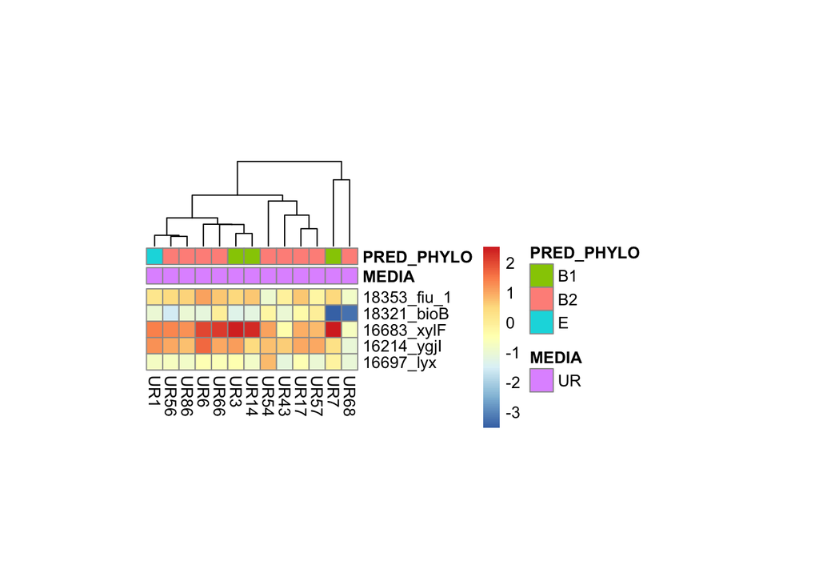

```r
pheatmap(load.genes.urine, annotation_col = annot, cellheight = 10, cellwidth = 10, cluster_rows = FALSE)#,
```

- Same for only UTI samples…

```r
annot = info[, c("MEDIA", "PRED_PHYLO")]
pca.data.uti <- prcomp(t.uti[,1:2502])
pc2.loadings.uti <- pca.data.uti$rotation[,2][order(pca.data.uti$rotation[,2], decreasing = TRUE)][1:20]#PC2
names.uti <- names(pc2.loadings.uti)
load.genes.uti <-inv.norm.c[names.uti, even]
head(names.uti, 10)
```

```
##  [1] "15176_wzc"
##  [2] "15748_rimM"
##  [3] "15747_trmD"
##  [4] "15177_wzb"
##  [5] "18446_nicotinamidase-pyrazinamidase"
##  [6] "15749_rpsP"
##  [7] "17023_sodA"
##  [8] "15750_ffh"
##  [9] "15010_argS"
## [10] "17141_hypothetical_protein"
```

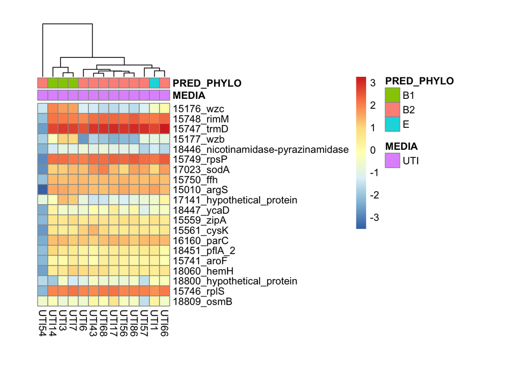

```r
pheatmap(load.genes.uti, annotation_col = annot, cellheight = 10, cellwidth = 10, cluster_rows = FALSE)#,
```

## 3. Run phylogenetic tests on genes identified to see if they show ‘phylogenetic signal’

- Have to remember how I did this before…